# Discussion 1

Tarin Phippen

# Preliminaries

- This file should be in `STAT240/discussion/ds01`.

The goal of today’s discussion will be to review the syllabus, think about your learning goals for STAT 240, and learn how to knit an Rmarkdown file to html.

# Problem 1

What are the dates for the first midterm, second midterm, and final exam for this course? As a reminder, makeup dates or times for the final exam are rarely offered and require extenuating or emergency circumstances.

### First midterm

Friday, Feb 27 during lecture

### Second midterm

Wednesday, Mar 25 during lecture

### Final exam

Thursday, May 7 from 7:25PM - 9:25PM

# Problem 2

What are your goals for taking this course and what are you hoping to learn?

This is a good introduction to Data Science for me. It will help me decide whether to pursue a certificate in Data Science or just go all in on Computer Science.

I hope to use my background in programming to excel in this class.

# Problem 3

Ensure that the `STAT240` folder on your computer is set up according to the image below.

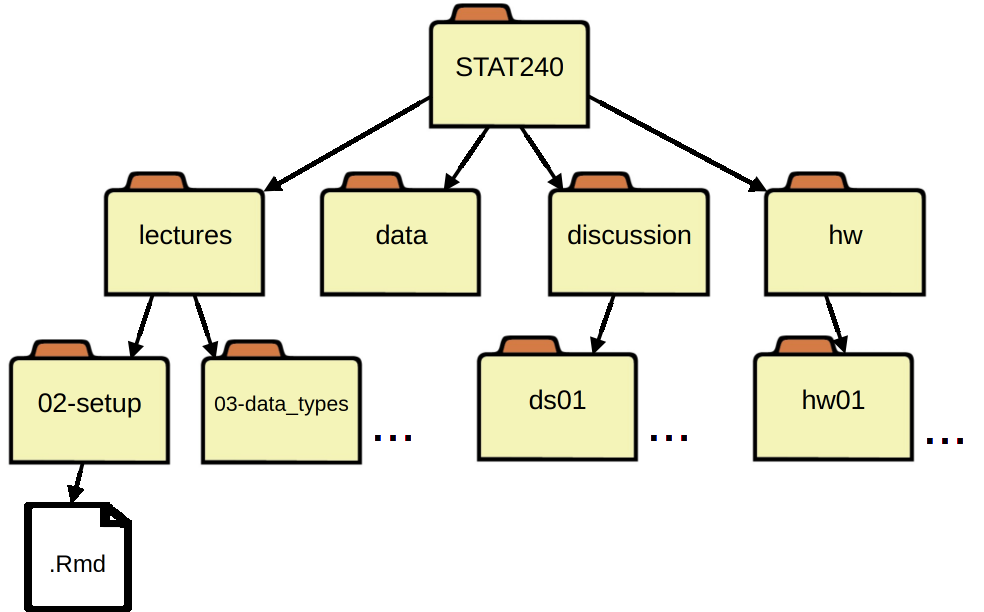

# Problem 4

Use the following R chunk to compute three squared plus five.

You may find [Section 2.3.2 of the textbook](https://bwu62.github.io/stat240-revamp/rstudio-intro.html#r-math) helpful.

```r
# Write your code in here!

3^2 + 5
```

```
## [1] 14
```

Ensure that the answer is appearing in the knitted file correctly. Do not just type the answer, write the code to get the answer.

# Submission

When you have answered the above questions, please knit this file and submit **both** the R Markdown file (.Rmd) and the knitted html file (.html).

We will ask for both files for every assignment in this course.

We will grade directly from the .html file, so make sure you are satisfied with how it looks before you submit. We ask for your .Rmd as a backup in case your .html file has errors in it.